# Mô Hình Hồi Quy Tuyến Tính

# Mục lục

- Thực hành
  - Tối ưu lồi
  - Bình phương tối tiểu
  - Mô hình hồi quy tuyến tính
- Đồ án : Linear Regression
  - Nội dung đồ án

# 1. Thực hành

Các phần được giới thiệu trong lab này là:

1. Bài toán tối ưu lồi
2. Bình phương tối tiểu
3. Mô hình hồi quy tuyến tính

```python
from matplotlib import pyplot as plt
import numpy as np
import sympy
from sympy import Matrix
from fractions import Fraction
```

## 1.1. Bài toán tối ưu lồi

Để khảo sát tính lồi lõm của hàm số nhiều biến, ta xét đạo hàm riêng cấp 1 và đạo hàm riêng cấp 2 của $f$.

**Ví dụ 1**. Xét tính lồi/lõm của hàm số sau $$f(x_1,x_2,x_3)=x_1^2+x_2^2+x_3^2-x_1x_2+x_1x_3$$

Ta có ma trận xác định dạng $A$ của hàm $f$ như sau $$A = \begin{bmatrix} 1 & -1/2 & 1/2\\ -1/2 & 1 & 0\\ 1/2 & 0 & 1 \end{bmatrix}$$ Để kiểm tra tính lồi/lõm của $f$, ta tìm các trị riêng ứng với ma trận $A$.

```python
A =np.array([[1,-1/2,1/2],[-1/2,1,0],[1/2,0,1]])
A
```

```
array([[ 1. , -0.5,  0.5],
       [-0.5,  1. ,  0. ],
       [ 0.5,  0. ,  1. ]])
```

```python
np.linalg.eig(A)[0]
```

```
array([1.70710678, 0.29289322, 1.        ])
```

Như vậy A là ma trận xác định dương nên $f$ là hàm lồi ngặt, $f$ có một điểm cực tiểu toàn cục duy nhất là **0**.

## 1.2. Bài toán bình phương tối tiểu (Least square)

Xét ma trận **A** có kích thước *m x n* (*m* > *n*) và vector **b** có kích thước *m*. Bình phương tối tiểu **$\hat{r}$** của **A** và **b** trên giá trị **$x$** được tính như sau:

**$$\hat{r} = ||Ax - b||^{2}$$** **$$\hat{x} = (A^TA)^{-1}A^Tb$$**

**Ví dụ** Cho ma trận **$A$** và vector cột **$b$** như sau \begin{align*} A=\begin{pmatrix} 2&0\\ -1&1\\ 0&2 \end{pmatrix}, b=\begin{pmatrix} 1\\0\\-1 \end{pmatrix} \end{align*} Tìm nghiệm của bài toán bình phương tối tiểu **$$||Ax - b||^{2}$$**

```python
A = np.array([[2, 0], [-1, 1], [0, 2]])
b = np.array([[1],[0],[-1]])
print(A)
print(b)
```

```
[[ 2  0]
 [-1  1]
 [ 0  2]]
[[ 1]
 [ 0]
 [-1]]
```

```python
C=np.matmul(np.transpose(A),A)
C
```

```
array([[ 5, -1],
       [-1,  5]])
```

```python
Y=np.matmul(np.transpose(A),b)
Y
```

```
array([[ 2],
       [-2]])
```

```python
xhat=np.matmul(np.linalg.inv(C),Y)
xhat
```

```
array([[ 0.33333333],
       [-0.33333333]])
```

Vậy nghiệm của bài toán bình phương tối tiểu đã cho ở trên là $\left(\dfrac{1}{3},-\dfrac{1}{3}\right)$

## 1.3. Mô hình hồi quy tuyến tính (Linear regression model)

Nghiệm **$\hat{x}$** của phương trình hồi quy tuyến tính **Ax = b** được tính như sau: **$$\hat{x} = (A^{T}A)^{-1}A^{T}b = A^{+}b$$**

Khảo sát 2 đại lượng **X,Y** . Cho bảng dữ liệu như sau:

| **X** | **Y** |
| --- | --- |
| 1 | 2 |
| 2 | 2 |
| 3 | 5 |
| 4 | 8 |

Với mỗi mô hình được cho, xác định các tham số của mô hình và tính chuẩn vector phần dư.

```python
xs = [1, 2, 3, 4]
ys = [2, 2, 5, 8]
print(xs, ys)
```

```
[1, 2, 3, 4] [2, 2, 5, 8]
```

Để thuận tiện xây dựng mô hình, hàm `getAb(xs,ys)` được viết.

### Input

- *xs, ys* lần lượt là vector dữ liệu của 2 biến **X,Y** ban đầu.

### Output

- hàm trả về ma trận dữ liệu **A** đã bổ sung thêm cột số 1 và ma trận cột **b** dùng để tìm các hệ số cho mô hình hồi quy.

### a) Mô hình tuyến tính $Y=\theta_1+\theta_2X$

```python
def getAb(xs, ys):
    col1 = np.ones(len(xs))
    colx = np.array(xs)
    A = np.array([col1, colx]).T
    b = np.array(ys).reshape(len(ys), 1)
    return A, b
```

```python
A, b = getAb(xs, ys)
A, b
```

```
(array([[1., 1.],
        [1., 2.],
        [1., 3.],
        [1., 4.]]),
 array([[2],
        [2],
        [5],
        [8]]))
```

```python
x_hat = np.linalg.inv(np.matmul(np.transpose(A),A)) @ np.matmul(np.transpose(A),b)
print(x_hat)
print(np.linalg.norm(A@x_hat - b))
```

```
[[-1. ]
 [ 2.1]]
1.6431676725154984
```

## Hàm `plt.plot(xpoints, ypoints,shortcut string)` trong Matplotlib

Hàm *plt.plot()* giúp vẽ các điểm nối các cặp điểm lần lượt trong *xpoints,ypoints*. Với mặc định của hàm là vẽ một đường thẳng để nối các điểm cho trước.

### Input:

- *xpoints, ypoints*: tọa độ của các điểm cần vẽ.
- *shortcut string*: phương thức dùng để nối các cặp điểm.

### Ouput:

- Hình vẽ sau khi nối *xpoints,ypoints*.

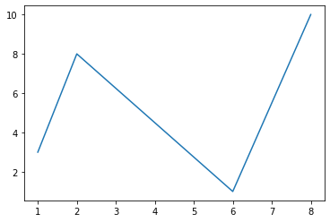

```python
import matplotlib.pyplot as plt
import numpy as np

xpoints = np.array([1, 2, 6, 8])
ypoints = np.array([3, 8, 1, 10])

plt.plot(xpoints, ypoints)
plt.show()
```

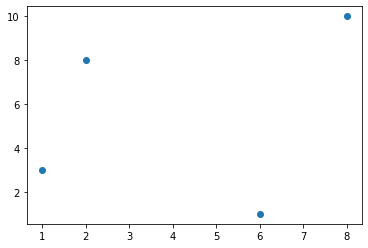

```python
import matplotlib.pyplot as plt
import numpy as np

xpoints = np.array([1, 2, 6, 8])
ypoints = np.array([3, 8, 1, 10])

plt.plot(xpoints, ypoints,'o')
plt.show()
```

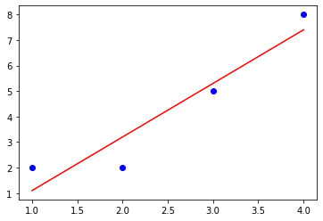

```python
import matplotlib.pyplot as plt

plt.plot(xs, ys, "o", color="blue")
ts = np.linspace(min(xs), max(xs), 50)
yts = [x_hat[0] + x_hat[1]*t for t in ts]
plt.plot(ts, yts, color="red")
plt.show()
```

### b) Mô hình $Y=\theta_1+\theta_2X^2$

```python
def getAb(xs, ys):
    col1 = np.ones(len(xs))
    colx = np.array(xs)
    A = np.array([col1, colx**2]).T
    b = np.array(ys).reshape(len(ys), 1)
    return A, b

def model(x, theta):
    return theta[0] + theta[1]*x**2
```

```python
A, b = getAb(xs, ys)
A, b
```

```
(array([[ 1.,  1.],
        [ 1.,  4.],
        [ 1.,  9.],
        [ 1., 16.]]),
 array([[2],
        [2],
        [5],
        [8]]))
```

```python
x_hat = np.linalg.inv(np.matmul(np.transpose(A),A)) @ np.matmul(np.transpose(A),b)
print(x_hat)
print(np.linalg.norm(A@x_hat - b))
```

```
[[1.02325581]
 [0.43023256]]
0.9338592095470355
```

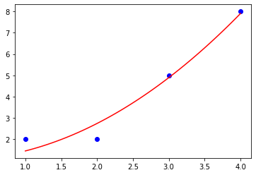

```python
import matplotlib.pyplot as plt

plt.plot(xs, ys, "o", color="blue")
ts = np.linspace(min(xs), max(xs), 50)
yts = [model(t, x_hat) for t in ts]
plt.plot(ts, yts, color="red")
plt.show()
```

### c) Mô hình $Y=\theta_1+\theta_2X+\theta_3X^2$

```python
def getAb(xs, ys):
    col1 = np.ones(len(xs))
    colx = np.array(xs)
    A = np.array([col1, colx, colx**2]).T
    b = np.array(ys).reshape(len(ys), 1)
    return A, b

def model(x, theta):
    return theta[0] + theta[1]*x + theta[2]*x**2
```

```python
A, b = getAb(xs, ys)
A, b
```

```
(array([[ 1.,  1.,  1.],
        [ 1.,  2.,  4.],
        [ 1.,  3.,  9.],
        [ 1.,  4., 16.]]),
 array([[2],
        [2],
        [5],
        [8]]))
```

```python
x_hat = np.linalg.inv(np.matmul(np.transpose(A),A)) @ np.matmul(np.transpose(A),b)
print(x_hat)
print(np.linalg.norm(A@x_hat - b))
```

```
[[ 2.75]
 [-1.65]
 [ 0.75]]
0.6708203932499369
```

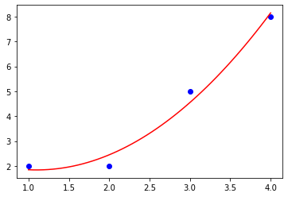

```python
import matplotlib.pyplot as plt

plt.plot(xs, ys, "o", color="blue")
ts = np.linspace(min(xs), max(xs), 50)
yts = [model(t, x_hat) for t in ts]
plt.plot(ts, yts, color="red")
plt.show()
```

### d) Mô hình tuyến tính - log: $Y=\theta_1+\theta_2lnX$

```python
def getAb(xs, ys):
    col1 = np.ones(len(xs))
    colx = np.array(xs)
    A = np.array([col1, np.log(colx)]).T
    b = np.array(ys).reshape(len(ys), 1)
    return A, b

def model(x, theta):
    return theta[0] + theta[1]*np.log(x)
```

```python
A, b = getAb(xs, ys)
A, b
```

```
(array([[1.        , 0.        ],
        [1.        , 0.69314718],
        [1.        , 1.09861229],
        [1.        , 1.38629436]]),
 array([[2],
        [2],
        [5],
        [8]]))
```

```python
x_hat = np.linalg.inv(np.matmul(np.transpose(A),A)) @ np.matmul(np.transpose(A),b)
print(x_hat)
print(np.linalg.norm(A@x_hat - b))
```

```
[[0.9795013 ]
 [4.11635406]]
2.525625919704245
```

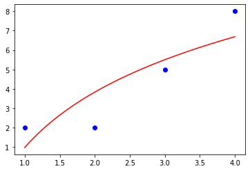

```python
import matplotlib.pyplot as plt

plt.plot(xs, ys, "o", color="blue")
ts = np.linspace(min(xs), max(xs), 50)
yts = [model(t, x_hat) for t in ts]
plt.plot(ts, yts, color="red")
plt.show()
```

### e) Mô hình log - tuyến tính: $lnY=\theta_1+\theta_2X$

```python
def getAb(xs, ys):
    col1 = np.ones(len(xs))
    colx = np.array(xs)
    A = np.array([col1, colx]).T
    b = np.log(np.array(ys).reshape(len(ys), 1))
    return A, b

def model(x, theta):
    return np.exp(theta[0] + theta[1]*x)
```

```python
A, b = getAb(xs, ys)
A, b
```

```
(array([[1., 1.],
        [1., 2.],
        [1., 3.],
        [1., 4.]]),
 array([[0.69314718],
        [0.69314718],
        [1.60943791],
        [2.07944154]]))
```

```python
x_hat = np.linalg.inv(np.matmul(np.transpose(A),A)) @ np.matmul(np.transpose(A),b)
print(x_hat)
print(np.linalg.norm(A@x_hat - b))
```

```
[[-8.88178420e-16]
 [ 5.07517382e-01]]
0.3847814582720001
```

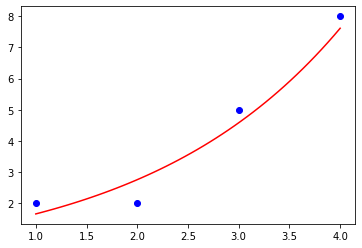

```python
import matplotlib.pyplot as plt

plt.plot(xs, ys, "o", color="blue")
ts = np.linspace(min(xs), max(xs), 50)
yts = [model(t, x_hat) for t in ts]
plt.plot(ts, yts, color="red")
plt.show()
```

### f) Mô hình log - log: $lnY=\theta_1+\theta_2lnX$

```python
def getAb(xs, ys):
    col1 = np.ones(len(xs))
    colx = np.array(xs)
    A = np.array([col1, np.log(colx)]).T
    b = np.log(np.array(ys).reshape(len(ys), 1))
    return A, b

def model(x, theta):
    return np.exp(theta[0] + theta[1]*np.log(x))
```

```python
A, b = getAb(xs, ys)
A, b
```

```
(array([[1.        , 0.        ],
        [1.        , 0.69314718],
        [1.        , 1.09861229],
        [1.        , 1.38629436]]),
 array([[0.69314718],
        [0.69314718],
        [1.60943791],
        [2.07944154]]))
```

```python
x_hat = np.linalg.inv(np.matmul(np.transpose(A),A)) @ np.matmul(np.transpose(A),b)
print(x_hat)
print(np.linalg.norm(A@x_hat - b))
```

```
[[0.4634213]
 [1.0136671]]
0.5673449282712967
```

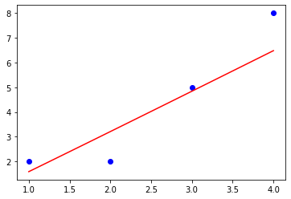

```python
import matplotlib.pyplot as plt

plt.plot(xs, ys, "o", color="blue")
ts = np.linspace(min(xs), max(xs), 50)
yts = [model(t, x_hat) for t in ts]
plt.plot(ts, yts, color="red")
plt.show()
```

## Đồ án 3: Linear regression

### Nội dung đồ án

```python
import pandas as pd
df = pd.read_csv('D:/Data/wine.csv', sep=';')
```

```python
df
```

|  | fixed acidity | volatile acidity | citric acid | residual sugar | chlorides | free sulfur dioxide | total sulfur dioxide | density | pH | sulphates | alcohol | quality |
| --- | --- | --- | --- | --- | --- | --- | --- | --- | --- | --- | --- | --- |
| 0 | 7.4 | 0.700 | 0.00 | 1.9 | 0.076 | 11.0 | 34 | 0.99780 | 3.51 | 0.56 | 9.4 | 5 |
| 1 | 7.8 | 0.880 | 0.00 | 2.6 | 0.098 | 25.0 | 67 | 0.99680 | 3.20 | 0.68 | 9.8 | 5 |
| 2 | 7.8 | 0.760 | 0.04 | 2.3 | 0.092 | 15.0 | 54 | 0.99700 | 3.26 | 0.65 | 9.8 | 5 |
| 3 | 11.2 | 0.280 | 0.56 | 1.9 | 0.075 | 17.0 | 60 | 0.99800 | 3.16 | 0.58 | 9.8 | 6 |
| 4 | 7.4 | 0.700 | 0.00 | 1.9 | 0.076 | 11.0 | 34 | 0.99780 | 3.51 | 0.56 | 9.4 | 5 |
| ... | ... | ... | ... | ... | ... | ... | ... | ... | ... | ... | ... | ... |
| 1194 | 7.0 | 0.745 | 0.12 | 1.8 | 0.114 | 15.0 | 64 | 0.99588 | 3.22 | 0.59 | 9.5 | 6 |
| 1195 | 6.2 | 0.430 | 0.22 | 1.8 | 0.078 | 21.0 | 56 | 0.99633 | 3.52 | 0.60 | 9.5 | 6 |
| 1196 | 7.9 | 0.580 | 0.23 | 2.3 | 0.076 | 23.0 | 94 | 0.99686 | 3.21 | 0.58 | 9.5 | 6 |
| 1197 | 7.7 | 0.570 | 0.21 | 1.5 | 0.069 | 4.0 | 9 | 0.99458 | 3.16 | 0.54 | 9.8 | 6 |
| 1198 | 7.7 | 0.260 | 0.26 | 2.0 | 0.052 | 19.0 | 77 | 0.99510 | 3.15 | 0.79 | 10.9 | 6 |

1199 rows × 12 columns

Xây dựng mô hình đánh giá chất lượng rượu sử dụng phương pháp hồi quy tuyến tính.

```
a. Sử dụng toàn bộ 11 đặc trưng đề bài cung cấp.

b. Sử dụng duy nhất 1 đặc trưng cho kết quả tốt nhất. (Gợi ý: Phương pháp Cross Validation)

c. Xây dựng một mô hình của riêng bạn cho kết quả tốt nhất.
```

### Quy định bài nộp

- Thực hiện toàn bộ bài làm trên 1 tập tin Jupyter Notebook (.ipynb) hoặc Python (.py)
- Bạn nộp tập tin `MSSV.zip` được nén từ thư mục MSSV chứa các tập tin sau:
  1. Báo cáo toàn bộ bài làm: `MSSV.pdf`
  2. Mã nguồn: `MSSV.ipynb` hoặc `MSSV.py`
- Trong đó, nội dung tập tin báo cáo gồm có:
  - Thông tin cá nhân: họ và tên, MSSV
  - Liệt kê các chức năng đã hoàn thành
  - Ý tưởng thực hiện, mô tả các hàm chức năng
  - Hình ảnh kết quả với từng chức năng
- Ví dụ minh họa cây thư mục bài nộp sau khi giải nén tập tin `MSSV.zip` như sau:

  ```
  MSSV
  ├── MSSV.pdf
  └── MSSV.ipynb
  ```

### Quy định chấm bài

Những trường hợp sau đây sẽ bị 0 điểm toàn bộ đồ án:

- Nộp sai quy định
- Không có báo cáo
- Thực thi mã nguồn báo lỗi

**LƯU Ý: SAO CHÉP BÀI LÀM CỦA NHAU SẼ BỊ 0 ĐIỂM TOÀN BỘ PHẦN THỰC HÀNH**